# Fansler et al., Nature Communications, Figure 1h

Sibylle Mitschka

Loading of R packages (not all may be required for this code section).

```r
library(tidyverse)
library(broom)
library(Biostrings)
library(ggpubr)
library(rtracklayer)
library(org.Hs.eg.db)
library(RColorBrewer)
library(biomaRt)
library(GenomicFeatures)
library(BSgenome)
library(GeneOverlap)
library(pheatmap)
library(biomaRt)
library(plyranges)
library(ggrepel)
library(writexl)
library(gridExtra)
library(readxl)
```

First, we create a histgram showing the proportion of CS that are used in either more or less than 10% of cell types in which the gene is detected. The data for this analysis are stored in Suppl. Data 1

```r
### MWS cleavage site atlas

CS_hs <- read_xlsx("Table_outputs/Suppl_Data1.xlsx", sheet="MWS CS Annots (HCL)")

plot_histogram_human <- ggplot(CS_hs, aes(x=cs_usage_score, fill=cs_usage_class))+
  geom_histogram(binwidth = 0.02)+
  scale_fill_manual(values=c("cadetblue","grey"))+
  theme_bw()

CS_hs %>% count(cs_usage_class)
```

| cs_usage_class | n |
| --- | --- |
| major | 39978 |
| minor | 35302 |
| NA | 3790 |

```r
ggsave("Figure_outputs/Fig1g.pdf", plot_histogram_human)
```

Comparison of the human MWS annoation with two other CS databases with regards to the number of 3’ends across protein-coding genes.

Procedure: We load information for all three annoations and convert them to GRanges. For the polyA_DB, we also need to convert the entries from Hg19 to Hg38 reference coordinates using the appropriate liftover chain files.

```r
CS_gr_hs <- makeGRangesFromDataFrame(CS_hs,
                         keep.extra.columns=TRUE,
                         ignore.strand=FALSE,
                         seqinfo=NULL,
                         seqnames.field="seq",
                         start.field="end_3p",
                         end.field="end_3p",
                         strand.field="strand",
                         starts.in.df.are.0based=FALSE)

### PolyAsite2.0

url <- "https://polyasite.unibas.ch/download/atlas/2.0/GRCh38.96/atlas.clusters.2.0.GRCh38.96.tsv.gz"

polA_site_hs <- read_tsv(url, col_names=TRUE) %>%
  dplyr::select(c(1:13))
colnames(polA_site_hs) <- c("chromosome", "start", "end", "cluster_id", "TPM", "strand",
                         "PAS_pos", "perc_samples_detected", "no_samples_detected","type",
                         "gene_name", "gene_id", "PAS")

polA_site_gr_hs <- makeGRangesFromDataFrame(polA_site_hs,
                         keep.extra.columns=TRUE,
                         ignore.strand=FALSE,
                         seqinfo=NULL,
                         seqnames.field= "Chromosome",
                         start.field="start",
                         end.field= "end",
                         strand.field= "strand",
                         starts.in.df.are.0based=FALSE)

seqlevelsStyle(polA_site_gr_hs) <- "UCSC"

### PolyA DB v3.2

url <- "https://exon.apps.wistar.org/polya_db/v3/download/3.2/human_pas.zip"
temp <- tempfile()
download.file(url,temp)
polA_db_hs <- read_tsv(temp)
unlink(temp)

polyA_db_gr_hs <- makeGRangesFromDataFrame(polA_db_hs,
                         keep.extra.columns=TRUE,
                         ignore.strand=FALSE,
                         seqinfo=NULL,
                         seqnames.field= "Chromosome",
                         start.field="Position",
                         end.field= "Position",
                         strand.field="Strand",
                         starts.in.df.are.0based=FALSE)

seqlevelsStyle(polyA_db_gr_hs) <- "UCSC"

#### perform liftover of granges from Hg19 to Hg38.

path = "input_data/annotation/hg19ToHg38.over.chain"

ch <- import.chain(path)

polyA_db_gr_38_hs <-  rtracklayer::liftOver(polyA_db_gr_hs, ch) %>%
  unlist()
```

Next, we are comparing the number of CS per gene for all three databases. For the MWS atlas, we are subsetting the pool to “major” CS (39,978 transcripts in 17,049 genes). For other e are restricting this analysis to protein-coding genes for which we rely on the gene labels that have been assigned by the individual databases.

```r
### Identify protein-coding genes and remove their gene_ID version labels.

gencode <- makeTxDbFromGFF("input_data/annotation/gencode.v39.mRNA_ends_found.gff3.gz")
```

```
## Import genomic features from the file as a GRanges object ... OK
## Prepare the 'metadata' data frame ... OK
## Make the TxDb object ...
```

```
## OK
```

```r
protein_coding_genes <- names(cdsBy(gencode, "gene")) %>% sub('\\.[0-9]*$', '', .)


## Prepare MWS atlas table (These CS are already restrcited to protein-coding genes).
MWS_major_census_hs <- CS_hs %>%
  dplyr::filter(cs_usage_class == "major") %>%
  count(gene_id) %>%
  count(n) %>%
  mutate(isoforms= ifelse(n<10, n, ">9")) %>%
  group_by(isoforms) %>%
  summarize(genes= sum(nn)) %>%
  mutate(DB= "MWS atlas, major isoforms")
```

```
## Storing counts in `nn`, as `n` already present in input
## ℹ Use `name = "new_name"` to pick a new name.
```

```r
### Protein-coding genes in MWS: 17049
CS_hs %>%
  dplyr::filter(cs_usage_class == "major") %>%
  count(gene_id) %>%
  nrow()
```

```
## [1] 17049
```

```r
### Prepare PolyA Site 2.0 table and filter to protein-coding genes.
polyA_site_census_hs <- polA_site_hs %>%
  dplyr::filter(gene_id %in% protein_coding_genes) %>%
  count(gene_id) %>%
  count(n) %>%
  mutate(isoforms= ifelse(n<10, n, ">9")) %>%
  group_by(isoforms) %>%
  summarize(genes= sum(nn)) %>%
  mutate(DB= "PolyASite 2.0")
```

```
## Storing counts in `nn`, as `n` already present in input
## ℹ Use `name = "new_name"` to pick a new name.
```

```r
### Protein-coding genes in PolyASite2.0: 17351
polA_site_hs %>%
  dplyr::filter(gene_id %in% protein_coding_genes) %>%
  count(gene_id) %>%
  nrow()
```

```
## [1] 17351
```

```r
### Prepare PolyA_DB table and filter to protein-coding genes.
polA_db_census_hs <- polA_db_hs %>%
  dplyr::filter(`Ensemble ID` %in% protein_coding_genes) %>%
  count(`Gene Symbol`) %>%
  count(n) %>%
  mutate(isoforms= ifelse(n<10, n, ">9")) %>%
  group_by(isoforms) %>%
  summarize(genes= sum(nn)) %>%
  mutate(DB= "PolyA_DB V3.2")
```

```
## Storing counts in `nn`, as `n` already present in input
## ℹ Use `name = "new_name"` to pick a new name.
```

```r
### Protein-coding genes in PolyASite2.0: 16872
polA_db_hs %>%
  dplyr::filter(`Ensemble ID` %in% protein_coding_genes) %>%
  count(`Gene Symbol`) %>%
  nrow()
```

```
## [1] 16872
```

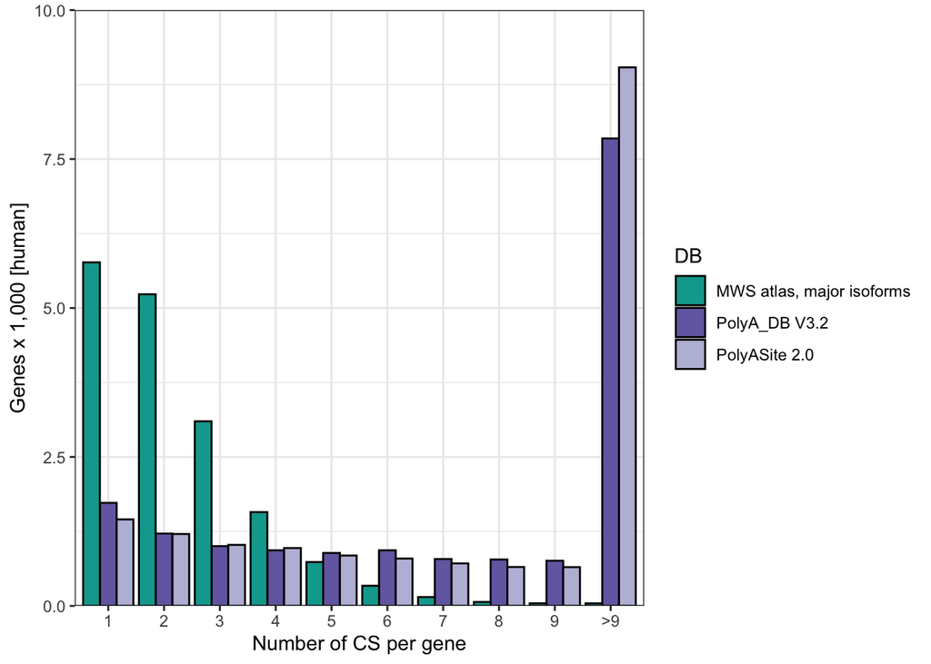

```r
### Combine all database tables into a single dataframe. Create a catorgory for genes with 10 or more CS.

hs_census <- rbind(polA_db_census_hs, polyA_site_census_hs, MWS_major_census_hs) %>%
  mutate(isoforms =factor(isoforms, levels=c(seq(1:9), ">9"))) %>%
  dplyr::filter(!is.na(isoforms))

### Create a distribution plot for human database entries. Save the output.

plot_hs <- ggplot(hs_census, aes(x=isoforms, y=genes/1000, fill=DB))+
  geom_col(position="dodge", col="black")+
  scale_y_continuous(limits = c(0,10), "Genes x 1,000 [human]", expand = c(0,0)) +
  scale_x_discrete("Number of CS per gene") +
  scale_fill_manual(values=c("#00a79d", "#756bb0", "#bcbddb"))+
  theme_bw()
plot_hs
```

```r
ggsave("Figure_outputs/Fig1h.pdf", plot_hs)
```

# Runtime Details

## Conda Environment

[output not shown]

[output cut: 602 more lines]

[output not shown]